# Water sensors

Presentation of Time Series exploration, anomaly detection, and predictions techniques

Python

Time Series

anomaly detection

Author

Łukasz Rąbalski

##### libraries

In the attached file you will find data containing two water sensors: water level and water velocity.

Column named “level” refers to raw level data and column named “velocity” refers to raw velocity data. Columns “final_level” and “final_velocity” refer to data that was manually corrected or removed because of malfunctions of sensors or other reasons. You have three tasks here:

1. Analyze the level and velocity data, find patterns, state own observations and conclusions.
2. Having the knowledge of what was corrected and statistical methods prepare simple solution to automatically find suspicious or corrupted data. (without using final columns to get the results, use them only as a reference).
3. Prepare a simple prediction model for both channels.

# 1 data exploration

> Analyze the level and velocity data, find patterns, state own observations and conclusions.

## 1.1 missing data

```python
import numpy as np
import pandas as pd
import math
df = pd.read_csv('/Users/lrabalski1/Desktop/prv/data/water_sensors.csv', parse_dates=["time"])
print('min time value: ',df.time.min(),'\n max time value: ',df.time.max())
## min time value:  2019-01-01 00:00:00
##  max time value:  2021-05-31 23:55:00
df=pd.DataFrame(
  pd.date_range('2019-01-01 00:00:00','2021-05-31 23:55:00',freq='5T'),
  columns=['time']
  ).merge(df, how='left', on=['time'])
df.index=df.time


print('NA within level_final: ',sum(df.level_final.isna()),'\nNA within velocity_final: ', sum(df.velocity_final.isna()))

## NA within level_final:  13725
## NA within velocity_final:  13725
df['level_data_malfunction']=(df.level.isna()) | (df.level!=df.level_final)
df['velocity_data_malfunction']=(df.velocity.isna()) | (df.velocity!=df.velocity_final)


# create a list of our conditions
conditions_level = [
    (df['level_data_malfunction'] ==False),
    (df['level_data_malfunction'] ==True) & ( df['level_final'].isna()),
    (df['level_data_malfunction'] ==True) & ( ~df['level_final'].isna())
    ]
values_level = [np.nan,'sensors_malfunction','manual_correction']
conditions_velocity = [
    (df['velocity_data_malfunction'] ==False),
    (df['velocity_data_malfunction'] ==True) & ( df['velocity_final'].isna()),
    (df['velocity_data_malfunction'] ==True) & ( ~df['velocity_final'].isna())
    ]
values_velocity = [np.nan,'sensors_malfunction','manual_correction']
df['velocity_reason_of_correction'] = np.select(conditions_velocity, values_velocity)
df['level_reason_of_correction'] = np.select(conditions_level, values_level)
print('\n\n')
```

Missing data in both variable (velocity and level), which can be explained as sensors malfunction, is observed in 13725 data points. For both variable missing data appears in the same datapoint. Probably sensors are responsible for measuring both measures.

Additionally in case of level measure we can observe 204 datapoint where data were manually corrected.

```python
print(pd.crosstab(df['velocity_reason_of_correction'],df['level_reason_of_correction']))
## level_reason_of_correction     manual_correction     nan  sensors_malfunction
## velocity_reason_of_correction
## nan                                          204  240087                    0
## sensors_malfunction                            0       0                13725
```

## 1.2 patterns

```python
import matplotlib.pyplot as plt
import seaborn as sns

df['time'] = pd.to_datetime(df['time'])
df_t=df.copy()
df_t.index = df_t['time']
df_t=df_t.drop(['time','level_data_malfunction', 'velocity_data_malfunction','velocity_reason_of_correction', 'level_reason_of_correction'], axis=1)

check=df_t.sort_values('level_final', ascending=False)
```

From the chart it can bee seen that:

- there is rather no trend within each timeseries
- in level data one big anomaly can be observed in the middle of a period

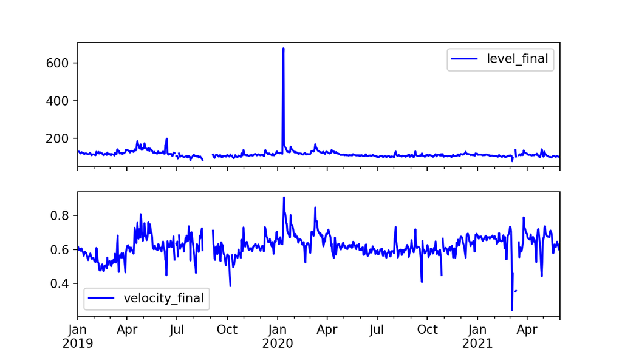

```python
# downsampling
df_M = df_t.resample("D").mean()

styles1 = ['b-','r-']
plt.clf()
fig, axes = plt.subplots(nrows=2, ncols=1, sharex=True)
df_M[['level_final']].plot(ax=axes[0],style=styles1)
df_M[['velocity_final']].plot(ax=axes[1],style=styles1)
plt.show()
```

```python
check=df_M.sort_values('level_final', ascending=False)
```

### 1.2.1 stationarity

As it can be seen on the both plots out time series seeme to be stationary, rolling mean and SD is stable within time.

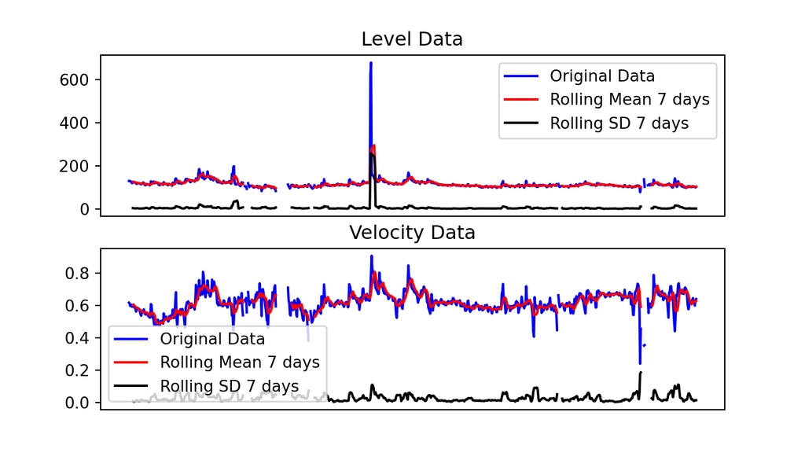

```python
rolling_mean = df_M.rolling(7).mean()
rolling_std = df_M.rolling(7).std()


#f, (ax1, ax2) = plt.subplots(2, 1, sharex=True)

plt.clf()
fig = plt.figure()
fig.add_subplot(2, 1, 1)

plt.plot(df_M['level_final'], color="blue",label="Original Data")
plt.plot(rolling_mean['level_final'], color="red", label="Rolling Mean 7 days")
plt.plot(rolling_std['level_final'], color="black", label = "Rolling SD 7 days")
plt.title("Level Data")
plt.xticks([])
## ([], [])
plt.legend(loc="best")

fig.add_subplot(2, 1, 2)
plt.plot(df_M['velocity_final'], color="blue",label="Original Data")
plt.plot(rolling_mean['velocity_final'], color="red", label="Rolling Mean 7 days")
plt.plot(rolling_std['velocity_final'], color="black", label = "Rolling SD 7 days")
plt.title("Velocity Data")
plt.legend(loc="best")
plt.xticks([])
## ([], [])
plt.show()
```

Stiationarity of a data is support by the fact that p-value of Dickey–Fuller test is lower than 5 percent (null hypothesis it claiming that time series is non-stationary) and the test statistic is lower than the critical value. We can also draw these conclusions from inspecting the data.

```python
from statsmodels.tsa.stattools import adfuller
adft_velocity = adfuller(df_M.dropna(subset=['velocity_final'])['velocity_final'],autolag="AIC")
adft_level = adfuller(df_M.dropna(subset=['level_final'])['level_final'],autolag="AIC")

adft=adft_level
output_level = pd.DataFrame({"Values":[adft[0],adft[1],adft[2],adft[3], adft[4]['1%'], adft[4]['5%'], adft[4]['10%']]  , "Metric":["Test Statistics","p-value","No. of lags used","Number of observations used",
                                                        "critical value (1%)", "critical value (5%)", "critical value (10%)"]})

adft=adft_velocity
output_velocity = pd.DataFrame({"Values":[adft[0],adft[1],adft[2],adft[3], adft[4]['1%'], adft[4]['5%'], adft[4]['10%']]  , "Metric":["Test Statistics","p-value","No. of lags used","Number of observations used",
                                                        "critical value (1%)", "critical value (5%)", "critical value (10%)"]})

results = pd.DataFrame(output_velocity.join(output_level, lsuffix='_velocity', rsuffix='_level'))
results
##    Values_velocity  ...                 Metric_level
## 0        -4.758844  ...              Test Statistics
## 1         0.000065  ...                      p-value
## 2         8.000000  ...             No. of lags used
## 3       841.000000  ...  Number of observations used
## 4        -3.438149  ...          critical value (1%)
## 5        -2.864983  ...          critical value (5%)
## 6        -2.568603  ...         critical value (10%)
##
## [7 rows x 4 columns]
```

```r
tabela(py$results)
```

| Values_velocity | Metric_velocity | Values_level | Metric_level |
| --- | --- | --- | --- |
| -4.7588442824438 | Test Statistics | -4.5674129740265 | Test Statistics |
| 6.51519038186205e-05 | p-value | 0.000148263119551768 | p-value |
| 8 | No. of lags used | 14 | No. of lags used |
| 841 | Number of observations used | 835 | Number of observations used |
| -3.43814949093876 | critical value (1%) | -3.43820570888786 | critical value (1%) |
| -2.86498279559325 | critical value (5%) | -2.86500757854652 | critical value (5%) |
| -2.56860322243917 | critical value (10%) | -2.56861642403815 | critical value (10%) |

### 1.2.2 autocorelation

We can see that both variable are weakly autocorelated, however velocity data better. Reason for bad autocorelation in level data measured this way, may have fact of big anomaly within dataset.

```python
def my_function(df,col, array):
  dicts = {}
  for idx, x in enumerate(array):
    dicts[x] = df[col].autocorr(x)
  return dicts
print('autocorelation of level data :')
## autocorelation of level data :
my_function(df_M,'level_final',array=[1,7,14,30,365])
## {1: 0.6187899970924978, 7: 0.16030304961078023, 14: 0.1660215318228444, 30: 0.08793288098871045, 365: 0.016746891095633046}
print('\n autocorelation of velocity data :')
##
##  autocorelation of velocity data :
my_function(df_M,'velocity_final',array=[1,7,14,30,365])
## {1: 0.822156599237431, 7: 0.4759130585597128, 14: 0.3678199431634758, 30: 0.15582363183139622, 365: -0.11352389683675475}
```

### 1.2.3 data imputation

I will choose best method based on longest period upon which I have full data.

Missing data is spread along all time range.

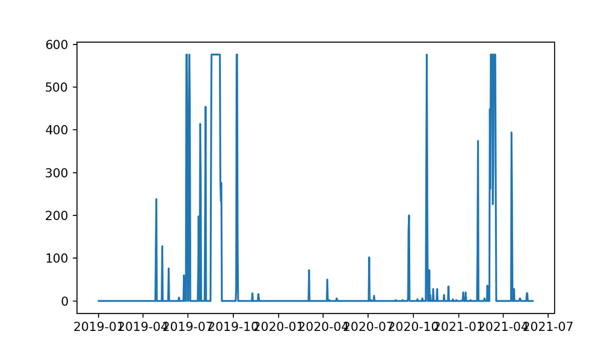

```python
df_na = df_t.copy()
df_na['time']=df_na.index
df_na = df_na.reset_index(drop=True)
df_na['date']=df_na['time'].dt.date
df_na['na_velocity_final'] = df_na.velocity_final.isna()
df_na['na_level_final'] = df_na.level_final.isna()
dates_with_na = df_na.groupby('date')[['na_level_final','na_velocity_final']].sum().reset_index()
dates_with_na['any_na'] = dates_with_na.sum(axis=1)
## <string>:1: FutureWarning: Dropping of nuisance columns in DataFrame reductions (with 'numeric_only=None') is deprecated; in a future version this will raise TypeError.  Select only valid columns before calling the reduction.
dates_with_na[dates_with_na.any_na > 0]
##            date  na_level_final  na_velocity_final  any_na
## 116  2019-04-27              58                 58     116
## 117  2019-04-28             119                119     238
## 129  2019-05-10              64                 64     128
## 142  2019-05-23              38                 38      76
## 163  2019-06-13               4                  4       8
## ..          ...             ...                ...     ...
## 854  2021-05-04               1                  1       2
## 855  2021-05-05               3                  3       6
## 856  2021-05-06               2                  2       4
## 869  2021-05-19               9                  9      18
## 870  2021-05-20               9                  9      18
##
## [105 rows x 4 columns]
plt.clf()
fig = plt.figure()
plt.plot(dates_with_na.date, dates_with_na.any_na)

plt.show()
```

```python
longest_consecutive_na_chain = (~df_na['na_level_final']).cumsum().value_counts()
longest_consecutive_na_chain = longest_consecutive_na_chain[longest_consecutive_na_chain!=1]-1


df_na.index = df_na['time']
longest_concecutive_full_data_chain  = (df_na['na_level_final']).cumsum()
longest_concecutive_full_data_chain_counts = longest_concecutive_full_data_chain.value_counts()

longest_concecutive_full_data_chain_counts=longest_concecutive_full_data_chain_counts[longest_concecutive_full_data_chain_counts!=1]-1

selected_chain = longest_concecutive_full_data_chain[longest_concecutive_full_data_chain==longest_concecutive_full_data_chain_counts.index[0]]
```

Any automatic technic od missing data imputation like:

- Mean, median and mode imputation
- Forward and backward filling
- linear / nearest imputation

could behave bad in such a kind o missing pattern (5476 consecutive data points is missing)

Thats why I will prepare two different imputation schema, check their accuracy for given dataset and choose better one:

- **Method 1**: fill the missing data with the averaged value of given second of year. For seconds from january to may i will have maximum 3 data points (2019;2020;2021); for rest maximum of 2 data points.
- **Method 2**:fill data with previous day data point with similar daytime

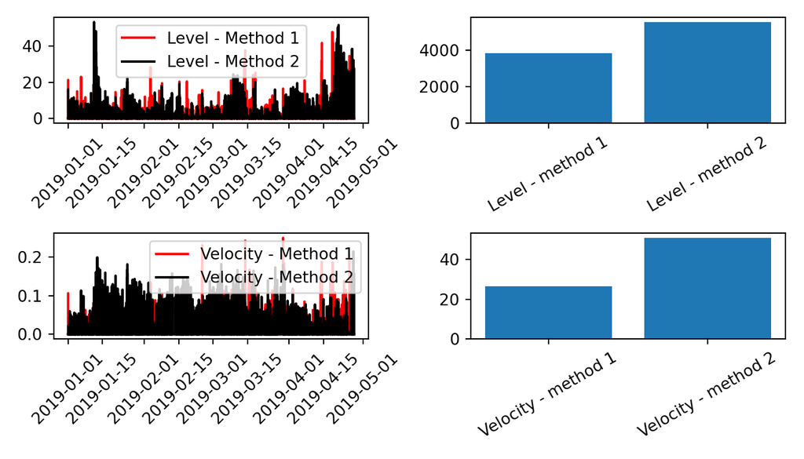

```python
# preparing dataset for Method 1
df_fill = df_t.copy()
df_fill['time']=df_fill.index
#df_fill = df_fill.reset_index(drop=True)
df_fill['time_agg'] = pd.DatetimeIndex(df_fill.time).strftime("%m-%d %H:%M:%S")
df_time_agg = df_fill.groupby('time_agg').agg(
  velocity_final_mean=('velocity_final','mean'),
  level_final_mean=('level_final','mean'),
  velocity_mean=('velocity','mean'),
  level_mean=('level','mean')
).reset_index()


#'after agregation to day of year I still have 54 missing value, which mostly come from one chain of missing data. I will replace them with data from previous day.')
#df_time_agg.isna().sum()

df_time_agg = df_time_agg.join(df_time_agg.shift(24*12), rsuffix='_lag_1_day')
df_time_agg.velocity_final_mean = df_time_agg.velocity_final_mean.fillna(df_time_agg.velocity_final_mean_lag_1_day)
df_time_agg.velocity_mean = df_time_agg.velocity_mean.fillna(df_time_agg.velocity_mean_lag_1_day)
df_time_agg.level_final_mean = df_time_agg.level_final_mean.fillna(df_time_agg.level_final_mean_lag_1_day)
df_time_agg.level_mean = df_time_agg.level_mean.fillna(df_time_agg.level_mean_lag_1_day)
df_time_agg = df_time_agg[df_time_agg.columns.drop(list(df_time_agg.filter(regex='_lag_1_day')))]


# testing two method
## preparing test data

df_test = df_fill.loc[selected_chain.index].copy()
df_test['velocity_final_missing'] = df_test.velocity_final
df_test['level_final_missing'] = df_test.level_final
rng = np.random.RandomState(42)
random_indices = rng.choice(range(len(df_test)), size=round(len(df_test)/50))
df_test = df_test.reset_index(drop=True)
df_test.loc[random_indices, ['velocity_final_missing','level_final_missing']] = np.nan


## fillig missing data
### time_agg method - Method 1
df_test = df_test.merge(df_time_agg, how='left', on =['time_agg'])
df_test.index = df_test['time']
df_test['velocity_final_fill_method_1'] = df_test.velocity_final_missing.fillna(df_test.velocity_final_mean)
df_test['level_final_fill_method_1'] = df_test.level_final_missing.fillna(df_test.level_final_mean)

### laged value - Method 2
cols= ['velocity_final_fill_method_2','level_final_fill_method_2']
time_shifts = np.array([-24*12,-24*12+1,-24*12-1,-24*12+2,-24*12-2,-24*12+3,-24*12-3,-24*12*2,-24*12*2+1,-24*12*2-1,-24*12*2+2,-24*12*2+2,-24*12*2+3,-24*12*2-3])

df_test['velocity_final_fill_method_2'] = df_test.velocity_final_missing
df_test['level_final_fill_method_2'] = df_test.level_final_missing

i=-1
while df_test[['velocity_final_fill_method_2','level_final_fill_method_2']].isna().sum().sum() >0:
  i=+1
  time_shifts = [x+1 for x in time_shifts]
  for col,time_shift in  ((x, y) for x in cols for y in time_shifts):
    #print (col,time_shift)
    df_test[col] = df_test[col].fillna(df_test[col].shift(time_shift))






# testing difference
level_dist_1 = abs(df_test.level_final_fill_method_2-df_test.level_final)
level_dist_2 = abs(df_test.level_final_fill_method_1-df_test.level_final)

velocity_dist_1 = abs(df_test.velocity_final_fill_method_2-df_test.velocity_final)
velocity_dist_2 = abs(df_test.velocity_final_fill_method_1-df_test.velocity_final)


plt.clf()
fig = plt.figure()
fig.add_subplot(2, 2, 1)

plt.plot(level_dist_1, color="red", label="Level - Method 1")
plt.plot(level_dist_2, color="black", label = "Level - Method 2")
#plt.title("Absolute Error for level missing data imputation")
plt.legend(loc="best")
plt.xticks(rotation=45)
## (array([17897., 17911., 17928., 17942., 17956., 17970., 17987., 18001.,
##        18017.]), [Text(0, 0, ''), Text(0, 0, ''), Text(0, 0, ''), Text(0, 0, ''), Text(0, 0, ''), Text(0, 0, ''), Text(0, 0, ''), Text(0, 0, ''), Text(0, 0, '')])
fig.add_subplot(2, 2, 2)
plt.bar(['Level - method 1','Level - method 2'], [level_dist_1.sum(),level_dist_2.sum()])
#plt.title("Absolute Error for level missing data imputation")
## <BarContainer object of 2 artists>
plt.xticks(rotation=30)
## ([0, 1], [Text(0, 0, ''), Text(0, 0, '')])
fig.add_subplot(2, 2, 3)
plt.plot(velocity_dist_1, color="red", label="Velocity - Method 1")
plt.plot(velocity_dist_2, color="black", label = "Velocity - Method 2")
#plt.title("Absolute Error for velocity missing data imputation")
plt.legend(loc="best")
plt.xticks(rotation=45)
## (array([17897., 17911., 17928., 17942., 17956., 17970., 17987., 18001.,
##        18017.]), [Text(0, 0, ''), Text(0, 0, ''), Text(0, 0, ''), Text(0, 0, ''), Text(0, 0, ''), Text(0, 0, ''), Text(0, 0, ''), Text(0, 0, ''), Text(0, 0, '')])
fig.add_subplot(2, 2, 4)
plt.bar(['Velocity - method 1','Velocity - method 2'], [velocity_dist_1.sum(),velocity_dist_2.sum()])
#plt.title("Absolute Error for level missing data imputation")
## <BarContainer object of 2 artists>
plt.xticks(rotation=30)
## ([0, 1], [Text(0, 0, ''), Text(0, 0, '')])
fig.tight_layout()
plt.show()
```

### 1.2.4 periodic decomposition

Both dataset show quite strong daily seasonality (level higher then velocity) Both dataset show weak weekly seasonality (again level higher then velocity) There is no observable trend in both variables.

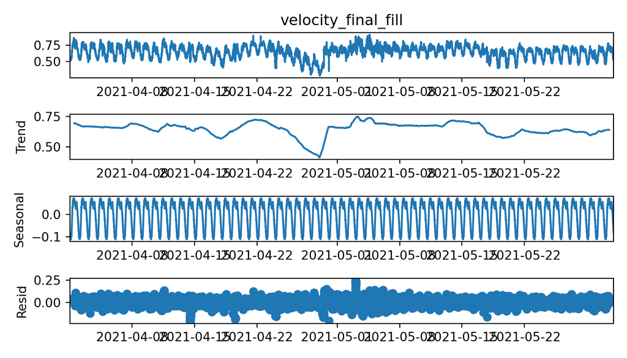

```python
from statsmodels.tsa.seasonal import seasonal_decompose




# daily seasonality
df_D = df_fill_final
decompose = seasonal_decompose(df_D.loc[df_D.index > '2021-04-01','velocity_final_fill'],model='additive', period = 12*24)
decompose.plot()
plt.show()
```

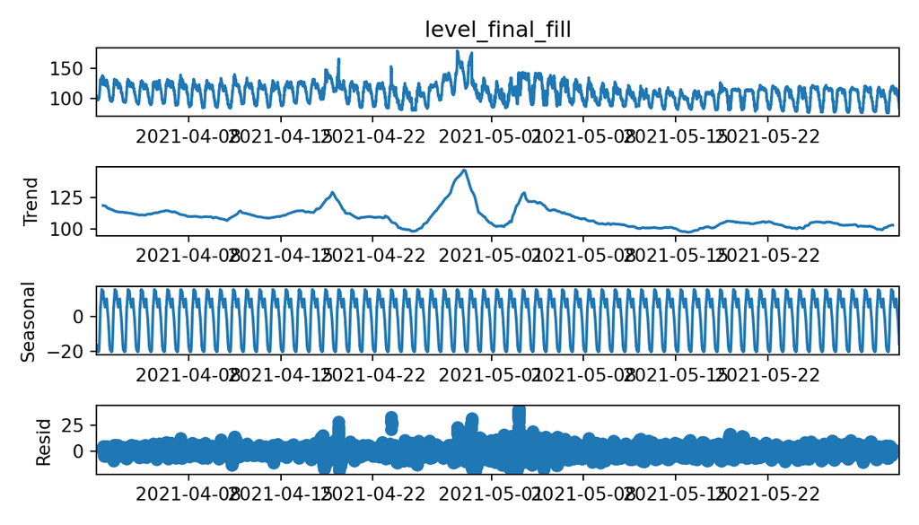

```python
decompose = seasonal_decompose(df_D.loc[df_D.index > '2021-04-01','level_final_fill'],model='additive', period = 12*24)
decompose.plot()
plt.show()

# weakly seasonality
```

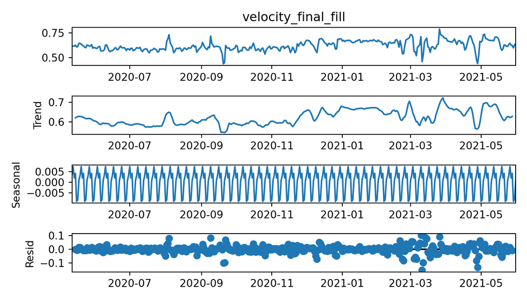

```python
df_D = df_fill_final.resample("D").mean()
decompose = seasonal_decompose(df_D.loc[df_D.index >= '2020-05-12','velocity_final_fill'],model='additive', period = 7)
decompose.plot()
plt.show()
```

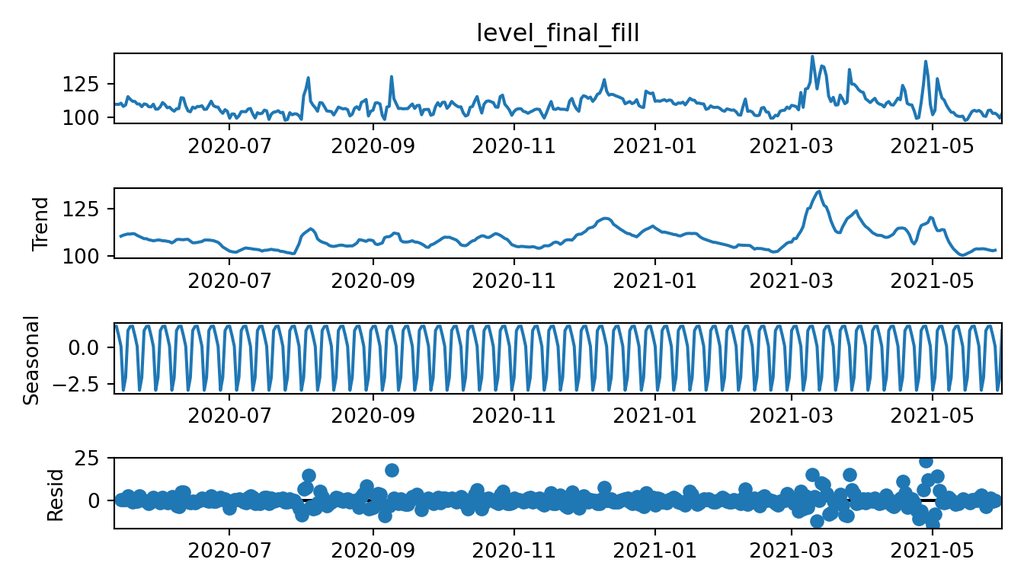

```python
decompose = seasonal_decompose(df_D.loc[df_D.index >= '2020-05-12','level_final_fill'],model='additive', period = 7)
decompose.plot()
plt.show()
```

# 2 automatically detect suspicious data

## 2.1 simple solution

> Having the knowledge of what was corrected … prepare simple solution to automatically find suspicious or corrupted data

Below I present two periods within which data correction of level variable took place. It shows that there is no more then 600 level value, while manuall correction reported that there were higher values to observe. Probably sensors are not able to make measurement above this level.

According to this my suggestion would be:

> **🚨** **when the measurement of level will hit 600 sound the alarm 🚨**

The data correction process which took place within 2019-06-13 was substle in size. Hard to be understooded without any extra information.

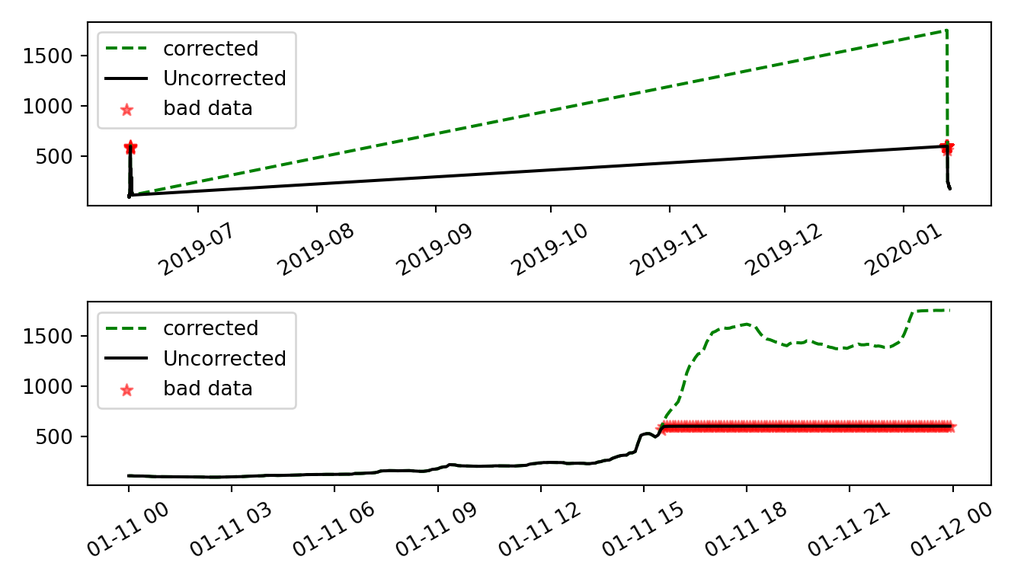

```python
a = df.loc[df['level_reason_of_correction'] == 'manual_correction', ['level']] #anomaly


sel_dates = (df.index>a.index.min()) & (df.index < a.index.max())
sel_dates_1 = np.isin(df.index.date,list(set(a.index.date))[0:2])
sel_dates_2 = np.isin(df.index.date,list(set(a.index.date))[2:])

a_1 = df.loc[(df['level_reason_of_correction'] == 'manual_correction') & (sel_dates_1==True), ['level']] #anomaly


a_2 = df.loc[(df['level_reason_of_correction'] == 'manual_correction') & (sel_dates_2==True), ['level']] #anomaly

check = df.loc[sel_dates_2,['level','level_final']]

plt.clf()
fig = plt.figure()

fig.add_subplot(2, 1, 1)
plt.plot( df.loc[sel_dates_1,['level_final']], color='green', label = 'corrected',linestyle='dashed')
plt.plot( df.loc[sel_dates_1,['level']], color='black', label = 'Uncorrected')
plt.scatter(a_1.index,a_1['level'], color='red', label = 'bad data',alpha=0.5, marker='*')
plt.xticks(rotation=30)
## (array([18078., 18109., 18140., 18170., 18201., 18231., 18262.]), [Text(0, 0, ''), Text(0, 0, ''), Text(0, 0, ''), Text(0, 0, ''), Text(0, 0, ''), Text(0, 0, ''), Text(0, 0, '')])
plt.legend()

fig.add_subplot(2, 1, 2)
plt.plot( df.loc[sel_dates_2,['level_final']], color='green', label = 'corrected',linestyle='dashed')
plt.plot( df.loc[sel_dates_2,['level']], color='black', label = 'Uncorrected')
plt.scatter(a_2.index,a_2['level'], color='red', label = 'bad data',alpha=0.5, marker='*')
plt.xticks(rotation=30)
## (array([18272.   , 18272.125, 18272.25 , 18272.375, 18272.5  , 18272.625,
##        18272.75 , 18272.875, 18273.   ]), [Text(0, 0, ''), Text(0, 0, ''), Text(0, 0, ''), Text(0, 0, ''), Text(0, 0, ''), Text(0, 0, ''), Text(0, 0, ''), Text(0, 0, ''), Text(0, 0, '')])
plt.legend()
fig.tight_layout()
plt.show();
```

## 2.2 Statistical method

> Having the knowledge of statistical methods prepare simple solution to automatically find suspicious or corrupted data.

In order to detect anomalies in dataset I used IsolationForest algorithm which identifies anomalies by isolating outliers in the data.

The `contamination` parameter defines a rough estimate of the percentage of the outliers in our dataset. Based on what i know about size of manual correction within my dataset I assigned contamination to be 0.1% in our case.

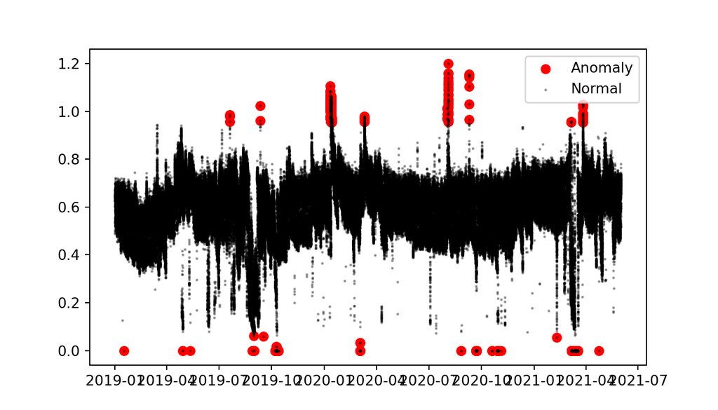

```python
random_state = np.random.RandomState(42)
outliers_fraction = float(round(np.mean(df['level_reason_of_correction']=='manual_correction'),ndigits=3))


scaler = StandardScaler()
np_scaled_velocity = scaler.fit_transform(df_fill_final.velocity_fill.values.reshape(-1, 1))
np_scaled_level = scaler.fit_transform(df_fill_final.level_fill.values.reshape(-1, 1))

data_velocity = pd.DataFrame(np_scaled_velocity)
data_level = pd.DataFrame(np_scaled_level)

#train isolation forest
model_velocity =  IsolationForest(contamination=outliers_fraction+0.01,random_state=random_state)
model_level =  IsolationForest(contamination=outliers_fraction,random_state=random_state)

model_velocity.fit(data_velocity)
## IsolationForest(contamination=0.011,
##                 random_state=RandomState(MT19937) at 0x2923E0940)
model_level.fit(data_level)
## IsolationForest(contamination=0.001,
##                 random_state=RandomState(MT19937) at 0x2923E0940)
df_fill_final['velocity_anomaly'] = model_velocity.predict(data_velocity)
df_fill_final['level_anomaly'] = model_level.predict(data_level)


# checking correctness
df.index = df['time']
df_fill_final = df_fill_final.join(df['level_reason_of_correction'])


# visualization

a = df_fill_final.loc[df_fill_final['velocity_anomaly'] == -1, ['velocity_fill']] #anomaly

plt.clf()
fig = plt.figure()
plt.scatter(a.index,a['velocity_fill'], color='red', label = 'Anomaly')
plt.scatter(df_fill_final.index, df_fill_final['velocity_fill'], color='black', label = 'Normal',s=1, alpha=0.3)
plt.legend()
plt.show();
```

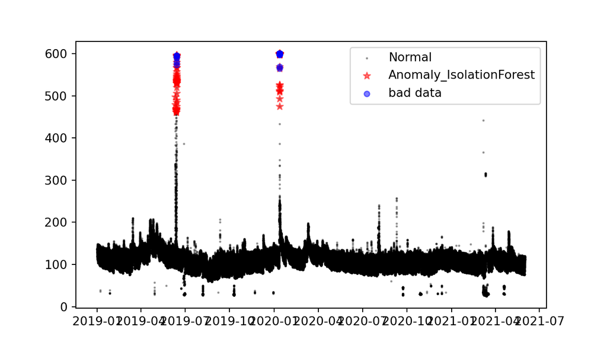

```python
a = df_fill_final.loc[(df_fill_final['level_anomaly'] == -1), ['level_fill']] #anomaly
a_true = df_fill_final.loc[(df_fill_final['level_reason_of_correction'] == 'manual_correction') , ['level_fill']] #anomaly


plt.clf()
fig = plt.figure()
plt.scatter(df_fill_final.index, df_fill_final['level_fill'], color='black', label = 'Normal',s=1, alpha=0.3)
plt.scatter(a.index,a['level_fill'], color='red', label = 'Anomaly_IsolationForest',alpha=0.5, marker='*')
plt.scatter(a_true.index,a_true['level_fill'], color='blue', label = 'bad data',alpha=0.5,marker='o',s=20)
plt.legend()
plt.show();
```

```python
df_fill_final['anomaly_detected'] = (df_fill_final['level_anomaly'] == -1)
df_fill_final['anomaly_true'] = df_fill_final['level_reason_of_correction'] == 'manual_correction'
```

IsolationForest managed to detect all manually coreccted data and additionally assign this label to 50 extra data points.

```python
print(pd.crosstab(df_fill_final['anomaly_detected'] ,df_fill_final['anomaly_true'] ))
## anomaly_true       False  True
## anomaly_detected
## False             253762     0
## True                  50   204
```

# 3 prediction model

> > Prepare a simple prediction model for both channels.

I prepare models which are trying to predict magnitude of level and velocity simply on the base of previous 5 day history of given measure.

Architecture of model is fully connected Neural Network that starts by flattening the data and then runs it through two Dense layers. I used mean squared error as the loss, rather than MAE, because unlike MAE, it’s smooth around zero, which is a useful property for gradient descent.

There are much better architectures designed for Time Series, like LSTM, however due to efficiency reason i chose this one (it tooks 20 seconds to learn this model on Macbook Pro M1, and additionally I faced some problem with running more LSTM model from keras on MacOS architecture).

Results of models were compared to Commons sense baseline. In case of predicting magnitude of measure 24 h from time point I assume that a common-sense approach is to always predict that the temperature 24 hours from now will be equal to the temperature right now.

For both channels models wasn’t able to beat Common sense baseline. I assume that basing on my past experience LSTM would be able.

```python
df_NN =  df_fill_final.copy()

analysed_variable='level'
column_name= analysed_variable + '_final_fill'
model_name = analysed_variable + '_model_recurrent.keras'



num_train_samples = int(0.5 * len(df_NN))
num_val_samples = int(0.25 * len(df_NN))
num_test_samples = len(df_NN) - num_train_samples - num_val_samples
print("num_train_samples:", num_train_samples)
print("num_val_samples:", num_val_samples)
print("num_test_samples:", num_test_samples)

# We’re going to use the first 127008 timesteps as training data, so we’ll compute the mean and standard deviation only on this fraction of the data.
mean = df_NN[:num_train_samples].mean(axis=0)
df_NN -= mean
std = df_NN[:num_train_samples].std(axis=0)
df_NN /= std

#Next, let’s create a Dataset object that yields batches of data from the past five days along with a target temperature 24 hours in the future.


import numpy as np
from tensorflow import keras



sampling_rate = 6 # 1 data point is 5 minut, setting sampling_rate = 6 means that i will take one data point for 30 minutes
sequence_length = 240 # 5 days =  5 * 24 * 2 = 1440
delay = sampling_rate * (sequence_length + 48 - 1)  # usefull equation allowing for calculating required delay ; 288 is one day, it means that I will predict measure 1 day later
batch_size = 256


# checking is it working ok

int_sequence = np.arange(288*24*24)
dummy_dataset = keras.utils.timeseries_dataset_from_array(
    data=int_sequence[:-delay],
    targets=int_sequence[delay:],
    sampling_rate= sampling_rate,
    sequence_length=sequence_length,
    #shuffle=True,
    batch_size=batch_size
)

for inputs, targets in dummy_dataset:
  break
df_NN.index[keras.backend.get_value(inputs[20][-1])]
df_NN.index[keras.backend.get_value(targets[20])]


# preparing dataset to learning, validating, testing and predicting


df_NN=df_NN.[column_name]

train_dataset = keras.utils.timeseries_dataset_from_array(
    df_NN[:-delay],
    targets=df_NN[column_name][delay:],
    sampling_rate=sampling_rate,
    sequence_length=sequence_length,
    shuffle=True,
    batch_size=batch_size,
    start_index=0,
    end_index=num_train_samples)

val_dataset = keras.utils.timeseries_dataset_from_array(
    df_NN[:-delay],
    targets=df_NN[column_name][delay:],
    sampling_rate=sampling_rate,
    sequence_length=sequence_length,
    shuffle=True,
    batch_size=batch_size,
    start_index=num_train_samples,
    end_index=num_train_samples + num_val_samples)

test_dataset = keras.utils.timeseries_dataset_from_array(
    df_NN[:-delay],
    targets=df_NN[column_name][delay:],
    sampling_rate=sampling_rate,
    sequence_length=sequence_length,
    shuffle=True,
    batch_size=batch_size,
    start_index=num_train_samples + num_val_samples)

predict_dataset = keras.utils.timeseries_dataset_from_array(
    df_NN[:-delay],
    targets=df_NN[column_name][delay:],
    sampling_rate=sampling_rate,
    sequence_length=sequence_length,
    shuffle=False,
    batch_size=batch_size
    )

#Each dataset yields a tuple (samples, targets), where samples is a batch of 256 samples, each containing 5 consecutive days of input data, and targets is the corresponding array of 256 target temperatures. Note that the samples are randomly shuffled, so two consecutive sequences in a batch (like samples[0] and samples[1]) aren’t necessarily temporally close.
for samples, targets in train_dataset:
     print("samples shape:", samples.shape)
     print("targets shape:", targets.shape)
     samples=samples
     targets=targets
     break


samples.shape
preds = samples[:, -1, 0] * std[0] + mean[0]
targets.shape
def evaluate_naive_method(dataset):
    total_abs_err = 0.
    samples_seen = 0
    for samples, targets_std in dataset:
        preds = samples[:, -1, 0] * std[0] + mean[0]
        targets = targets_std * std[0] + mean[0]
        total_abs_err += np.sum(np.abs(preds - targets))
        samples_seen += samples.shape[0]
    return total_abs_err / samples_seen

print(f"Validation MAE: {evaluate_naive_method(val_dataset):.2f}")
print(f"Test MAE: {evaluate_naive_method(test_dataset):.2f}")

from tensorflow.keras import layers

inputs = keras.Input(shape=(sequence_length, df_NN.shape[-1]))
x = layers.Flatten()(inputs)
x = layers.Dense(16, activation="relu")(x)
outputs = layers.Dense(1)(x)

# inputs = keras.Input(shape=(None,  df_NN.shape[-1]))
# outputs = layers.SimpleRNN(16)(inputs)


model = keras.Model(inputs, outputs)

callbacks = [
    keras.callbacks.ModelCheckpoint(model_name,
                                    save_best_only=True)
]
model.compile(optimizer="rmsprop", loss="mse", metrics=["mae"])
history = model.fit(train_dataset,
                    epochs=10,
                    validation_data=val_dataset,
                    callbacks=callbacks)

model = keras.models.load_model(model_name)
print(f"Test MAE: {model.evaluate(test_dataset)[1]:.2f}")


import matplotlib.pyplot as plt
loss = history.history["mae"]
val_loss = history.history["val_mae"]
epochs = range(1, len(loss) + 1)
plt.figure()
plt.plot(epochs, loss, "bo", label="Training MAE")
plt.plot(epochs, val_loss, "b", label="Validation MAE")
plt.title("Training and validation MAE")
plt.legend()
plt.show()


df_NN_final = df_NN.copy()
y_pred_array = model.predict(predict_dataset)* std[0] + mean[0]
y_pred = pd.Series(np.ravel(y_pred_array), name='predict')
y_pred.index += delay
df_NN_final['time'] = df_NN_final.index
df_NN_final[column_name] = df_NN_final[column_name] * std[0] + mean[0]
df_NN_final = df_NN_final.reset_index(drop=True)
df_NN_final = df_NN_final.join(y_pred)



import matplotlib.pyplot as plt
df_NN_final[[column_name,'predict']].plot()
df_NN_final.index=df_NN_final.time


plt.clf()
fig = plt.figure()
plt.scatter(df_NN_final.index[-10000:-1],df_NN_final[column_name][-10000:-1], color='green', label = 'Anomaly_2',alpha=0.02, marker='*')
plt.scatter(df_NN_final.index[-10000:-1],df_NN_final['predict'][-10000:-1], color='blue', label = 'Anomaly_2',alpha=0.02, marker='*')
plt.ylim((0.4,0.8))
plt.show();
```

[output not shown]